# Data-580 Lab 3

Dhun Sheth

2023-09-25

## Question 1

#### Part A

$$F(x)=log(x) => U=log(x) =>
x=e^U$$

#### Part B

```r
U <- runif(100000)
x <- exp(U)
```

#### Part C

```r
mean_x <- mean(x)
var_x <- var(x)
prob_x_less_than_2 <- mean(x < 2)
```

$E[x]=$ 1.7180235  
$Var[x]=$ 0.2424204  
$P(x < 2)=$ 0.69273

#### Part D

$$pdf=\frac{d}{dx}cdf =
\frac{d}{dx}log(x)=\frac{1}{x}=f(x)$$
$$E[x]=\int_a^{b}x*f(x)dx =
\int_1^{e}1~dx=[x]_1^e=e-1=1.7182818$$
1.7182818

$$E[x^2]=\int_a^{b}x^2*f(x)dx =
\int_1^{e}x~dx=[\frac{x^2}{2}]_1^e=\frac{e^2-1}{2}=3.194528$$
3.194528

$$Var[x]=E[x^2]-E[x]^2=3.194528 ~-
1.7182818^2= 0.2420357$$

0.2420357  
Comparing to the mean and variance estimate from Part C, we can see the values are very close.

## Question 2

#### Part A

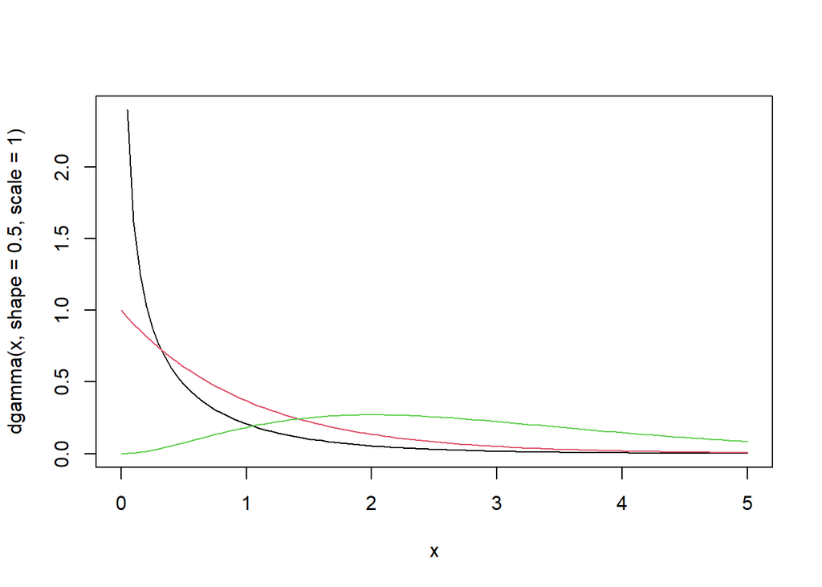

```r
curve(dgamma(x, shape = 0.5, scale = 1), 0, 5)
curve(dgamma(x, shape = 1, scale = 1), 0, 5, add=TRUE, col=2)
curve(dgamma(x, shape = 3, scale = 1), 0, 5, add = TRUE, col=3)
```

Density curve with shape=0.5 and scale=1 is decreasing to 0 as x goes to infinity, and approached infinity as x goes to 0.

Density curve with shape=1 and scale=1 is decreasing to 0 as x goes to infinity, and approaches 1 as x goes to 0.

#### Part B

```r
prob_3 <- pgamma(3, shape=5, scale=2)
prob_7 <- pgamma(7, shape=5, scale=2)
```

$P(x<=3)=$ 0.0185759  
$P(x<=7)=$ 0.274555

#### Part C

```r
x <- rgamma(100000, shape=5, scale=2)
sim_prob_3<-mean(x<=3)
sim_prob_7<-mean(x<=7)
```

Simulated and theoretical values are close to each other.

Simulated Values:  
$P(x<=3)=$ 0.01857  
$P(x<=7)=$ 0.27522

Theoretical Values:  
$P(x<=3)=$ 0.0185759  
$P(x<=7)=$ 0.274555

## Question 3

#### Part A

```r
prob_norm_3 <- pnorm(3, mean=5, sd=2)
prob_norm_7 <- pnorm(7, mean=5, sd=2)
```

$P(x<=3)=$ 0.1586553  
$P(x<=7)=$ 0.8413447

#### Part B

```r
x_norm <- rnorm(10000, mean=5, sd=2)
sim_norm_prob_3<-mean(x_norm<=3)
sim_norm_prob_7<-mean(x_norm<=7)
```

Simulated and theoretical values are very close to each other.

Simulated Values:  
$P(x<=3)=$ 0.1614  
$P(x<=7)=$ 0.8404

Theoretical Values:  
$P(x<=3)=$ 0.1586553  
$P(x<=7)=$ 0.8413447

#### Part C

##### Part i., ii., iii.

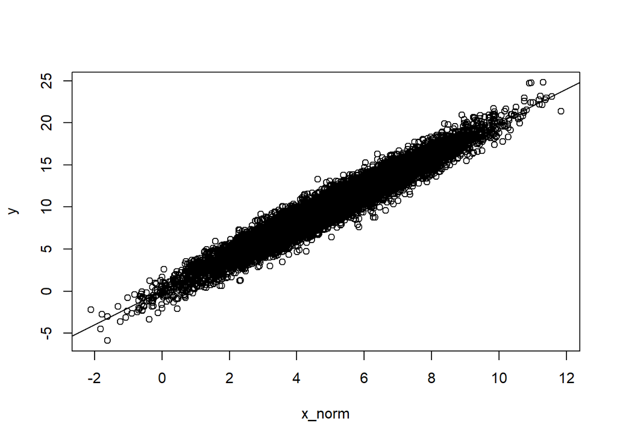

```r
z_norm <- rnorm(10000)
y <- 2*x_norm + z_norm

plot(x_norm,y)
abline(0,2)
```

The (x,y) scatter plot forms a linear pattern which is concentrated around (5,10) and goes down in density as x moves away from 5.

Because x_norm has a standard deviation of 2, and z has a standard deviation of 1, I would expect y = 2x, and so I would expect abline(0,2) which is the line y(x)=2x to pass through the middle of scatter plot (x,y)….and this is exactly what happens.

#### Part D

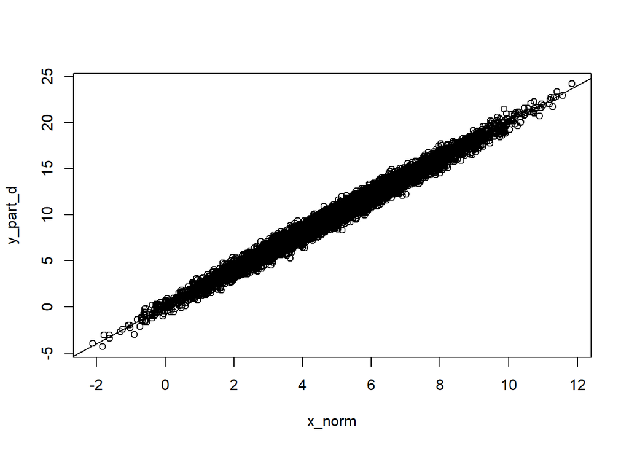

```r
z_norm_changed <- rnorm(10000, mean=0, sd=0.5)
y_part_d <- 2*x_norm + z_norm_changed

plot(x_norm,y_part_d)
abline(0,2)
```

#### Part E

The scatter plot with z having a standard deviation of 0.5 becomes more closer to the line y(x)=2x.  
As the standard deviation of z gets larger than 1, the standard deviation of y will also get larger and the scatter plot will move away from a linear pattern matching the line y(x)=2x, and as the standard deviation of z gets smaller and closer to 0, the scatter plot will converge to the line y(x)=2x.